# Tree-Based Methods

To prune the tree with regression tree model, we can use following code:

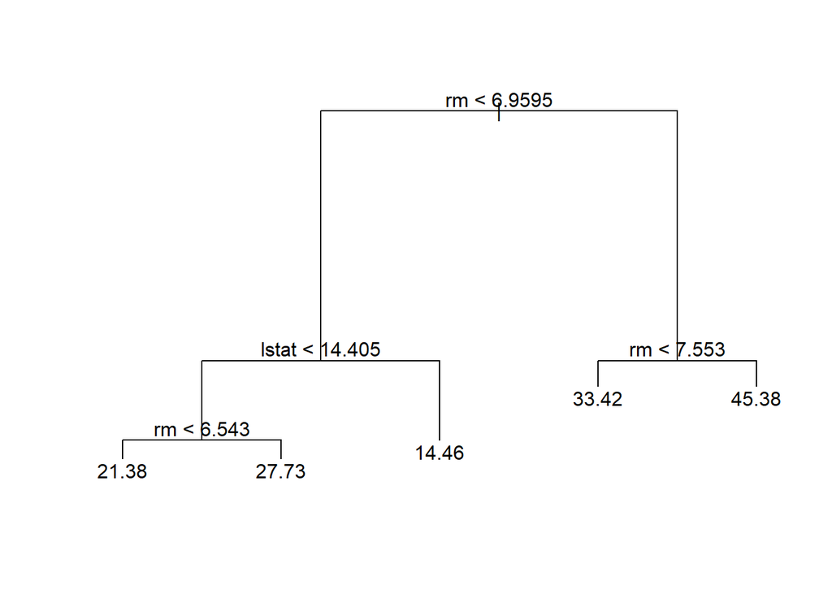

```r
#Step 3: Prune the tree
prune.boston=prune.tree(tree.boston ,best=5)
plot(prune.boston)
text(prune.boston , pretty =0)
```

For the pruned model with 5 nodes, we noticed that the two leaves under crime rate branch were removed.

Now, we will use the original model with 7 nodes to fit testing data.

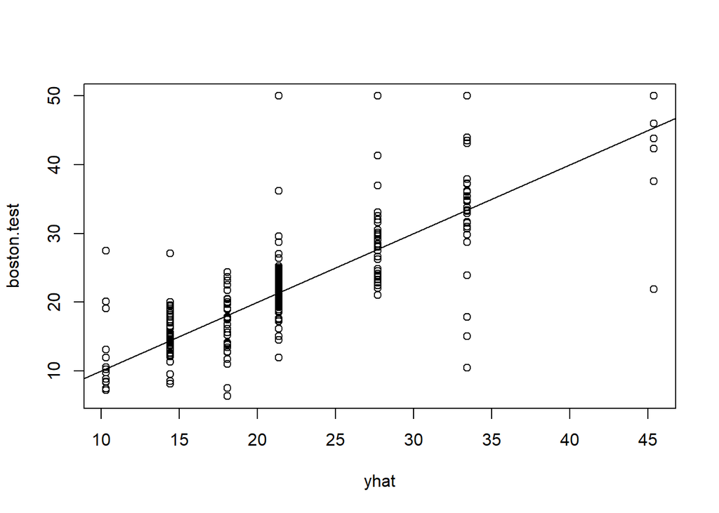

```r
#Step 4: Predict testing data
yhat=predict (tree.boston ,newdata=Boston[-train ,])
boston.test=Boston[-train ,"medv"]
plot(yhat ,boston.test)
abline (0,1)
```

```r
mean((yhat -boston.test)^2)
```

```
## [1] 35.28688
```

The mse of the test set is 35.28688. The square root of mse is 5.940276.Therefore, with the current model, we can predict testing data within $5,940 of the true median home values.

### Applied Lab: Question 8

```r
set.seed(4)
train = sample (1:nrow(Carseats), nrow(Carseats)/2)
tree.carseats=tree(Sales~.,Carseats , subset=train)
```

```r
summary(tree.carseats)
```

```
##
## Regression tree:
## tree(formula = Sales ~ ., data = Carseats, subset = train)
## Variables actually used in tree construction:
## [1] "ShelveLoc"   "Age"         "Price"       "Advertising" "CompPrice"
## Number of terminal nodes:  13
## Residual mean deviance:  2.26 = 422.6 / 187
## Distribution of residuals:
##     Min.  1st Qu.   Median     Mean  3rd Qu.     Max.
## -3.89500 -0.96890 -0.06955  0.00000  1.06700  3.70100
```

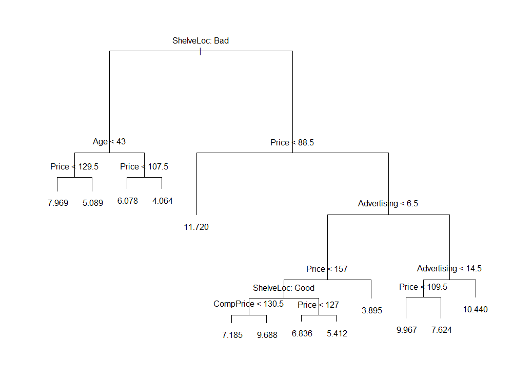

```r
plot(tree.carseats)
text(tree.carseats , pretty =0)
```

```r
yhat.carseats = predict(tree.carseats, newdata = Carseats[-train ,])
test.carseats = Carseats[-train, "Sales"]
mean((yhat.carseats- test.carseats)^2)
```

```
## [1] 6.334268
```

This MSE is at 6.334!

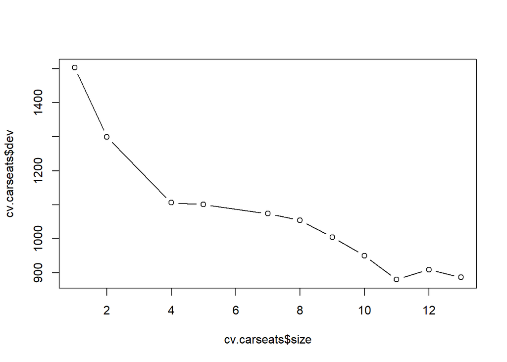

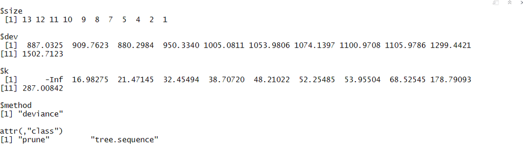

```r
cv.carseats=cv.tree(tree.carseats)
plot(cv.carseats$size ,cv.carseats$dev ,type='b')
```

```r
prune.carseats=prune.tree(tree.carseats ,best=11)
```

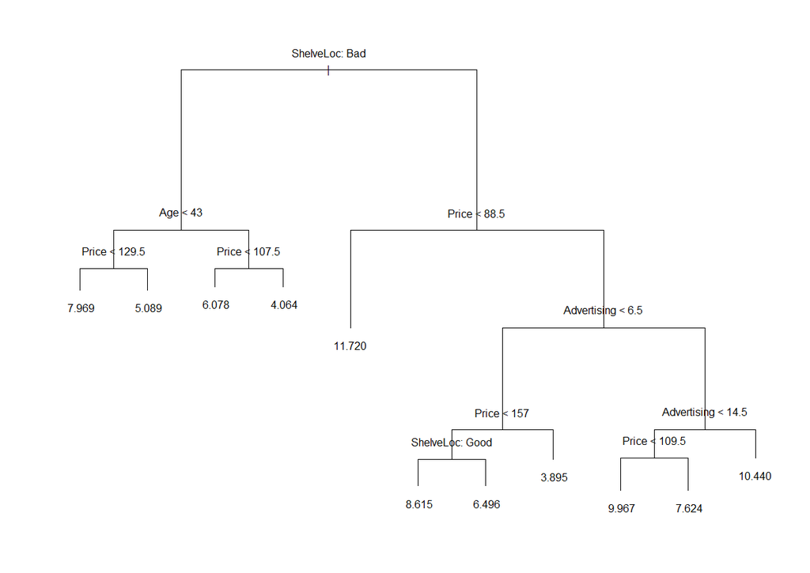

```r
plot(prune.carseats)
text(prune.carseats , pretty =0)
```

```r
yhat.prune.carseats=predict (prune.carseats ,newdata=Carseats[-train ,])
mean((yhat.prune.carseats -test.carseats)^2) ##6.40863
```

```
## [1] 6.40863
```

Pruning results is slightly higher than the full tree MSE (6.409 > 6.334). This means that pruning the tree did not yield a better result. As such, going with the original full tree is the recommended model.